# Capstone Project - NLP Chatbot

### DOMAIN:

Industrial safety. NLP based Chatbot.

### CONTEXT:

The database comes from one of the biggest industry in Brazil and in the world. It is an urgent need for industries/companies around the globe to understand why employees still suffer some injuries/accidents in plants. Sometimes they also die in such environment.

### DATA DESCRIPTION:

This The database is basically records of accidents from 12 different plants in 03 different countries which every line in the data is an occurrence of an accident.

### Columns description:

- Data: timestamp or time/date information
- Countries: which country the accident occurred (anonymised)
- Local: the city where the manufacturing plant is located (anonymised)
- Industry sector: which sector the plant belongs to
- Accident level: from I to VI, it registers how severe was the accident (I means not severe but VI means very severe)
- Potential Accident Level: Depending on the Accident Level, the database also registers how severe the accident could have been (due to other factors involved in the accident)
- Gender: if the person is male of female
- Employee or Third Party: if the injured person is an employee or a third party
- Critical Risk: some description of the risk involved in the accident
- Description: Detailed description of how the accident happened.

Link to download the dataset: https://drive.google.com/file/d/1_GmrRP1S2OIa02KlfOBNkYa8uxazGbfE/view?usp=sharing, Original dataset link: https://www.kaggle.com/ihmstefanini/industrial-safety-and-health-analytics-database

### PROJECT OBJECTIVE:

Design a ML/DL based chatbot utility which can help the professionals to highlight the safety risk as per the incident description.

```python
from google.colab import drive
drive.mount('/content/drive')
```

Replace the folder path with your drive folder path and clone the githb repo

```python
%cd /content/drive/MyDrive/Capstone
```

```
/content/drive/MyDrive/Capstone
```

Run the below code for clone the repo in our Googele drive for first time

```python
! git clone https://github.com/shyamsparrow/Jan-G4---NLP-Chatbot.git
```

```
Cloning into 'Jan-G4---NLP-Chatbot'...
remote: Enumerating objects: 319, done.
remote: Counting objects: 100% (319/319), done.
remote: Compressing objects: 100% (314/314), done.
remote: Total 319 (delta 162), reused 0 (delta 0), pack-reused 0
Receiving objects: 100% (319/319), 27.53 MiB | 5.18 MiB/s, done.
Resolving deltas: 100% (162/162), done.
```

Change the Current folder into Github repo main folder, all the functions we are calling has to be in this repo.

```python
%cd /content/drive/MyDrive/Capstone/Jan-G4---NLP-Chatbot
```

```
/content/drive/MyDrive/Capstone/Jan-G4---NLP-Chatbot
```

```python
!git config --global user.email "pradeebha.ab@gmail.com"
!git config --global user.name "Pradeebha"
```

```python
!git status
```

```
No commits yet

Changes to be committed:
  (use "git rm --cached <file>..." to unstage)

	new file:   AIML Capstone Project - NLP chatbot.pdf
	new file:   Capstone_NLP_Chatbot_Jan_A_G4.ipynb
	new file:   Chatbot.ipynb
	new file:   Data Set - industrial_safety_and_health_database_with_accidents_description.csv
	new file:   GL Bot.json
	new file:   NLP_text_preprocess.py
	new file:   Pradeebha_Capstone_NLP_Chatbot_Jan_A_G4.ipynb
	new file:   README.md
	new file:   config.py
	new file:   data/custom_substitutions.csv
	new file:   data/ignore_spellcheck_words.txt
	new file:   industry_df_preprocessed.csv
	new file:   industry_df_with_stopwords.csv
```

```python
!git commit -m "My message"
```

[output not shown]

Run this code to update the changes in repo to our drive

```python
!git pull
```

```
remote: Enumerating objects: 71, done.
remote: Counting objects: 100% (71/71), done.
remote: Compressing objects: 100% (59/59), done.
remote: Total 64 (delta 30), reused 4 (delta 2), pack-reused 0
Unpacking objects: 100% (64/64), done.
From https://github.com/shyamsparrow/Jan-G4---NLP-Chatbot
   ad132d0..0231d57  Models               -> origin/Models
 * [new branch]      VemulaGanesh-patch-1 -> origin/VemulaGanesh-patch-1
   a2fc3f4..85be9ed  main                 -> origin/main
You are not currently on a branch.
Please specify which branch you want to merge with.
See git-pull(1) for details.

    git pull <remote> <branch>
```

```python
import warnings
warnings.filterwarnings('ignore')

import config
from wordcloud import WordCloud,STOPWORDS
import nltk
from nltk.corpus import stopwords
from bs4 import BeautifulSoup
import string
import numpy as np
import pandas as pd
import seaborn as sns
import matplotlib.pyplot as plt
import re
```

```python
url = "Data Set - industrial_safety_and_health_database_with_accidents_description.csv"
industry_df = pd.read_csv(url, index_col = 0)
industry_df.head
```

```
<bound method NDFrame.head of                     Data  ...                                        Description
0    2016-01-01 00:00:00  ...  While removing the drill rod of the Jumbo 08 f...
1    2016-01-02 00:00:00  ...  During the activation of a sodium sulphide pum...
2    2016-01-06 00:00:00  ...  In the sub-station MILPO located at level +170...
3    2016-01-08 00:00:00  ...  Being 9:45 am. approximately in the Nv. 1880 C...
4    2016-01-10 00:00:00  ...  Approximately at 11:45 a.m. in circumstances t...
..                   ...  ...                                                ...
434  2017-07-04 00:00:00  ...  Being approximately 5:00 a.m. approximately, w...
435  2017-07-04 00:00:00  ...  The collaborator moved from the infrastructure...
436  2017-07-05 00:00:00  ...  During the environmental monitoring activity i...
437  2017-07-06 00:00:00  ...  The Employee performed the activity of strippi...
438  2017-07-09 00:00:00  ...  At 10:00 a.m., when the assistant cleaned the ...

[425 rows x 10 columns]>
```

```python
industry_df.shape
```

```
(425, 10)
```

### Re-naming the column name:

We have 10 columns( features) and 425 rows of data. Let us Rename the column correctly, which is misspelled.

```python
industry_df.rename(columns={'Data':'Date', 'Countries':'Country', 'Genre':'Gender', 'Employee or Third Party':'Employee_type',
'Industry Sector':'Industry_Sector','Accident Level':'Accident_Level','Potential Accident Level':'Potential_Accident_Level',
'Critical Risk':'Critical_Risk'}, inplace=True)
industry_df.head(3)
```

|  | Date | Country | Local | Industry_Sector | Accident_Level | Potential_Accident_Level | Gender | Employee_type | Critical_Risk | Description |
| --- | --- | --- | --- | --- | --- | --- | --- | --- | --- | --- |
| 0 | 2016-01-01 00:00:00 | Country_01 | Local_01 | Mining | I | IV | Male | Third Party | Pressed | While removing the drill rod of the Jumbo 08 f... |
| 1 | 2016-01-02 00:00:00 | Country_02 | Local_02 | Mining | I | IV | Male | Employee | Pressurized Systems | During the activation of a sodium sulphide pum... |
| 2 | 2016-01-06 00:00:00 | Country_01 | Local_03 | Mining | I | III | Male | Third Party (Remote) | Manual Tools | In the sub-station MILPO located at level +170... |

### Checking Missing Values:

```python
datatype = pd.DataFrame(industry_df.dtypes)
datatype['MissingVal'] = industry_df.isnull().sum()
datatype['NUnique']=industry_df.nunique()
datatype
```

|  | 0 | MissingVal | NUnique |
| --- | --- | --- | --- |
| Date | object | 0 | 287 |
| Country | object | 0 | 3 |
| Local | object | 0 | 12 |
| Industry_Sector | object | 0 | 3 |
| Accident_Level | object | 0 | 5 |
| Potential_Accident_Level | object | 0 | 6 |
| Gender | object | 0 | 2 |
| Employee_type | object | 0 | 3 |
| Critical_Risk | object | 0 | 33 |
| Description | object | 0 | 411 |

By Checking the missing value, we have 0 missing values in all 10 columns.

### Removing Duplicates:

```python
industry_df.duplicated().sum()
```

```
7
```

We have 7 duplicate values, let us check those values and remove it

```python
duplicates = industry_df.duplicated()
industry_df[duplicates]
```

|  | Date | Country | Local | Industry_Sector | Accident_Level | Potential_Accident_Level | Gender | Employee_type | Critical_Risk | Description |
| --- | --- | --- | --- | --- | --- | --- | --- | --- | --- | --- |
| 89 | 2016-04-01 00:00:00 | Country_01 | Local_01 | Mining | I | V | Male | Third Party (Remote) | Others | In circumstances that two workers of the Abrat... |
| 276 | 2016-12-01 00:00:00 | Country_01 | Local_03 | Mining | I | IV | Male | Employee | Others | During the activity of chuteo of ore in hopper... |
| 317 | 2017-01-21 00:00:00 | Country_02 | Local_02 | Mining | I | I | Male | Third Party (Remote) | Others | Employees engaged in the removal of material f... |
| 359 | 2017-03-02 00:00:00 | Country_03 | Local_10 | Others | I | I | Male | Third Party | Venomous Animals | On 02/03/17 during the soil sampling in the re... |
| 360 | 2017-03-02 00:00:00 | Country_03 | Local_10 | Others | I | I | Male | Third Party | Venomous Animals | On 02/03/17 during the soil sampling in the re... |
| 369 | 2017-03-15 00:00:00 | Country_03 | Local_10 | Others | I | I | Male | Third Party | Venomous Animals | Team of the VMS Project performed soil collect... |
| 411 | 2017-05-23 00:00:00 | Country_01 | Local_04 | Mining | I | IV | Male | Third Party | Projection of fragments | In moments when the 02 collaborators carried o... |

```python
industry_df.drop_duplicates(inplace=True)
industry_df.shape
```

```
(418, 10)
```

```python
industry_df["Description"].nunique()
```

```
411
```

One can observe in the above dataframe that there are only 411 unique values in the Description column but we have 418 number of records in total, we can assume that there are still 7 number of duplicate values on description column. We will check for those duplicates on column level and drop if required for further analysis.

```python
print('There are still {} duplicates in the dataset as below'.format(industry_df.duplicated(subset=['Description'],keep=False).sum()))
industry_df[industry_df.duplicated(subset=['Description'],keep=False)].sort_values(by='Description')
```

```
There are still 14 duplicates in the dataset as below
```

|  | Date | Country | Local | Industry_Sector | Accident_Level | Potential_Accident_Level | Gender | Employee_type | Critical_Risk | Description |
| --- | --- | --- | --- | --- | --- | --- | --- | --- | --- | --- |
| 180 | 2016-07-07 00:00:00 | Country_01 | Local_03 | Mining | IV | V | Male | Third Party | Others | At moments when the MAPERU truck of plate F1T ... |
| 181 | 2016-07-07 00:00:00 | Country_01 | Local_03 | Mining | I | IV | Male | Third Party | Others | At moments when the MAPERU truck of plate F1T ... |
| 275 | 2016-12-01 00:00:00 | Country_01 | Local_03 | Mining | I | IV | Male | Employee | Others | During the activity of chuteo of ore in hopper... |
| 277 | 2016-12-01 00:00:00 | Country_01 | Local_03 | Mining | I | IV | Male | Third Party | Others | During the activity of chuteo of ore in hopper... |
| 426 | 2017-06-20 00:00:00 | Country_01 | Local_01 | Mining | I | IV | Male | Employee | Others | In circumstance, the AHK-903 license plate (Em... |
| 427 | 2017-06-20 00:00:00 | Country_01 | Local_01 | Mining | I | IV | Male | Third Party | Others | In circumstance, the AHK-903 license plate (Em... |
| 142 | 2016-05-26 00:00:00 | Country_03 | Local_10 | Others | I | I | Male | Third Party | Bees | In the geological reconnaissance activity, in ... |
| 143 | 2016-05-26 00:00:00 | Country_03 | Local_10 | Others | I | I | Male | Employee | Others | In the geological reconnaissance activity, in ... |
| 155 | 2016-06-08 00:00:00 | Country_03 | Local_10 | Others | I | I | Male | Third Party | Bees | Project of Vazante that carried out sediment c... |
| 156 | 2016-06-08 00:00:00 | Country_03 | Local_10 | Others | I | I | Male | Third Party | Others | Project of Vazante that carried out sediment c... |
| 401 | 2017-05-06 00:00:00 | Country_02 | Local_07 | Mining | IV | V | Male | Employee | Projection | The employees Márcio and Sérgio performed the ... |
| 402 | 2017-05-06 00:00:00 | Country_02 | Local_07 | Mining | II | V | Male | Employee | Projection | The employees Márcio and Sérgio performed the ... |
| 37 | 2016-02-24 00:00:00 | Country_02 | Local_07 | Mining | I | V | Male | Employee | Others | When starting the activity of removing a coil ... |
| 38 | 2016-02-24 00:00:00 | Country_02 | Local_07 | Mining | I | V | Female | Third Party | Others | When starting the activity of removing a coil ... |

We can cleary observe that the above dataframe contains 7 duplicates in which only one or two column values are dissimilar among the datapoints where in the Description is matching, which is logically unsound. It can also be noticed that the incidents which are having duplicate values happened on the time stamp(Date Column). Hence we will be dropping these hidden duplicates which doesn't seem right logically.

```python
# Dropping the duplicates we detected above.
industry_df.drop_duplicates(subset=['Description'], keep='first', inplace=True)
print('After removing duplicates the shape of the dataset is:', industry_df.shape)
```

```
After removing duplicates the shape of the dataset is: (411, 10)
```

### Checking Outliers:

```python
for x in industry_df.columns:
    if x != 'Description' and x != 'Date':
        print('--'*30); print(f'Unique values of "{x}" column'); print('--'*30)
        print(industry_df[x].unique())
        print("\n")
```

```
------------------------------------------------------------
Unique values of "Country" column
------------------------------------------------------------
['Country_01' 'Country_02' 'Country_03']


------------------------------------------------------------
Unique values of "Local" column
------------------------------------------------------------
['Local_01' 'Local_02' 'Local_03' 'Local_04' 'Local_05' 'Local_06'
 'Local_07' 'Local_08' 'Local_10' 'Local_09' 'Local_11' 'Local_12']


------------------------------------------------------------
Unique values of "Industry_Sector" column
------------------------------------------------------------
['Mining' 'Metals' 'Others']


------------------------------------------------------------
Unique values of "Accident_Level" column
------------------------------------------------------------
['I' 'IV' 'III' 'II' 'V']


------------------------------------------------------------
Unique values of "Potential_Accident_Level" column
------------------------------------------------------------
['IV' 'III' 'I' 'II' 'V' 'VI']


------------------------------------------------------------
Unique values of "Gender" column
------------------------------------------------------------
['Male' 'Female']


------------------------------------------------------------
Unique values of "Employee_type" column
------------------------------------------------------------
['Third Party' 'Employee' 'Third Party (Remote)']


------------------------------------------------------------
Unique values of "Critical_Risk" column
------------------------------------------------------------
['Pressed' 'Pressurized Systems' 'Manual Tools' 'Others'
 'Fall prevention (same level)' 'Chemical substances' 'Liquid Metal'
 'Electrical installation' 'Confined space'
 'Pressurized Systems / Chemical Substances'
 'Blocking and isolation of energies' 'Suspended Loads' 'Poll' 'Cut'
 'Fall' 'Bees' 'Fall prevention' '\nNot applicable' 'Traffic' 'Projection'
 'Venomous Animals' 'Plates' 'Projection/Burning' 'remains of choco'
 'Vehicles and Mobile Equipment' 'Projection/Choco' 'Machine Protection'
 'Power lock' 'Burn' 'Projection/Manual Tools'
 'Individual protection equipment' 'Electrical Shock'
 'Projection of fragments']
```

By checking all the unique values of all columns in the dataset, we can say there is no Outlier in this column.

We have only 3 countries, 12 Locals, 3 Industry sectors, 5 accident levels, 6 potential accident levels, 3 Employee types and 33 Critical Risks including Not applicable.

Five type of accident levels (1 to 5) are present. Six type of Potential Accident Levels (1 to 6) and we see that there is only one value registered under 'Accident level 6'

```python
industry_df['Potential_Accident_Level'] = industry_df['Potential_Accident_Level'].replace('VI', 'V')
```

```python
industry_df = industry_df.reset_index(drop=True)
```

Removed all Duplicate values

```python
industry_df.describe()
```

|  | Date | Country | Local | Industry_Sector | Accident_Level | Potential_Accident_Level | Gender | Employee_type | Critical_Risk | Description |
| --- | --- | --- | --- | --- | --- | --- | --- | --- | --- | --- |
| count | 411 | 411 | 411 | 411 | 411 | 411 | 411 | 411 | 411 | 411 |
| unique | 287 | 3 | 12 | 3 | 5 | 5 | 2 | 3 | 33 | 411 |
| top | 2017-02-08 00:00:00 | Country_01 | Local_03 | Mining | I | IV | Male | Third Party | Others | The operator of the paste filling plant 01 rem... |
| freq | 6 | 245 | 87 | 232 | 303 | 138 | 390 | 180 | 223 | 1 |

We have 411 unique descriptions in the dataset.

```python
print(industry_df.Date.min())
print(industry_df.Date.max())
```

```
2016-01-01 00:00:00
2017-07-09 00:00:00
```

The Accidents are captured in the year 2016- January to 2017 July. ~ 19 months of data.

Let us split the date value into year, month, day, name of the day and week of the year.

```python
industry_df['Date'] = pd.to_datetime(industry_df['Date'])
industry_df['Year'] = industry_df['Date'].apply(lambda x : x.year)
industry_df['Month'] = industry_df['Date'].apply(lambda x : x.month)
industry_df['Day'] = industry_df['Date'].apply(lambda x : x.day)
industry_df['Weekday'] = industry_df['Date'].apply(lambda x : x.day_name())
industry_df['WeekofYear'] = industry_df['Date'].apply(lambda x : x.weekofyear)
industry_df.head(3)
```

|  | Date | Country | Local | Industry_Sector | Accident_Level | Potential_Accident_Level | Gender | Employee_type | Critical_Risk | Description | Year | Month | Day | Weekday | WeekofYear |
| --- | --- | --- | --- | --- | --- | --- | --- | --- | --- | --- | --- | --- | --- | --- | --- |
| 0 | 2016-01-01 | Country_01 | Local_01 | Mining | I | IV | Male | Third Party | Pressed | While removing the drill rod of the Jumbo 08 f... | 2016 | 1 | 1 | Friday | 53 |
| 1 | 2016-01-02 | Country_02 | Local_02 | Mining | I | IV | Male | Employee | Pressurized Systems | During the activation of a sodium sulphide pum... | 2016 | 1 | 2 | Saturday | 53 |
| 2 | 2016-01-06 | Country_01 | Local_03 | Mining | I | III | Male | Third Party (Remote) | Manual Tools | In the sub-station MILPO located at level +170... | 2016 | 1 | 6 | Wednesday | 1 |

Accordin to this discussion, countries where the dataset was collected is anonymized but they are all located in South America. So in this analysis, let's assume the dataset was collected in Brazil. It is said in this web page that Brazil has four climatological seasons as below.

- Spring : September to November
- Summer : December to February
- Autumn : March to May
- Winter : June to August

We can create seasonal variable based on month variable.

```python
def month2seasons(x):
    if x in [9, 10, 11]:
        season = 'Spring'
    elif x in [12, 1, 2]:
        season = 'Summer'
    elif x in [3, 4, 5]:
        season = 'Autumn'
    elif x in [6, 7, 8]:
        season = 'Winter'
    return season
```

```python
industry_df['Season'] = industry_df['Month'].apply(month2seasons)
industry_df.head(3)
```

|  | Date | Country | Local | Industry_Sector | Accident_Level | Potential_Accident_Level | Gender | Employee_type | Critical_Risk | Description | Year | Month | Day | Weekday | WeekofYear | Season |
| --- | --- | --- | --- | --- | --- | --- | --- | --- | --- | --- | --- | --- | --- | --- | --- | --- |
| 0 | 2016-01-01 | Country_01 | Local_01 | Mining | I | IV | Male | Third Party | Pressed | While removing the drill rod of the Jumbo 08 f... | 2016 | 1 | 1 | Friday | 53 | Summer |
| 1 | 2016-01-02 | Country_02 | Local_02 | Mining | I | IV | Male | Employee | Pressurized Systems | During the activation of a sodium sulphide pum... | 2016 | 1 | 2 | Saturday | 53 | Summer |
| 2 | 2016-01-06 | Country_01 | Local_03 | Mining | I | III | Male | Third Party (Remote) | Manual Tools | In the sub-station MILPO located at level +170... | 2016 | 1 | 6 | Wednesday | 1 | Summer |

Let us check the time date and the spread of data across time.

```python
year_data = pd.DataFrame(industry_df.dtypes)
year_data['NUnique']=industry_df.nunique()
year_data.iloc[10:16]
```

|  | 0 | NUnique |
| --- | --- | --- |
| Year | int64 | 2 |
| Month | int64 | 12 |
| Day | int64 | 31 |
| Weekday | object | 7 |
| WeekofYear | int64 | 53 |
| Season | object | 4 |

```python
datelist = ['Year','Month','Day','Weekday','Season']
for x in datelist:
    print('--'*30); print(f'Unique values of "{x}" column'); print('--'*30)
    print(industry_df[x].unique())
    print("\n")
```

```
------------------------------------------------------------
Unique values of "Year" column
------------------------------------------------------------
[2016 2017]


------------------------------------------------------------
Unique values of "Month" column
------------------------------------------------------------
[ 1  2  3  4  5  6  7  8  9 10 11 12]


------------------------------------------------------------
Unique values of "Day" column
------------------------------------------------------------
[ 1  2  6  8 10 12 16 17 19 26 28 30  4  7 21 25  9 15 14 13 20 18 22 24
 29 27  3  5 11 31 23]


------------------------------------------------------------
Unique values of "Weekday" column
------------------------------------------------------------
['Friday' 'Saturday' 'Wednesday' 'Sunday' 'Tuesday' 'Thursday' 'Monday']


------------------------------------------------------------
Unique values of "Season" column
------------------------------------------------------------
['Summer' 'Autumn' 'Winter' 'Spring']
```

- We have accidents happened between 2016 to 2017 as per year column.
- The accidents is spread across all months, days and weekday.

Install pyspellchecker library for spell check.

```python
!pip install contractions
!pip install pyspellchecker
verbose= False
```

```
     |████████████████████████████████| 284 kB 4.9 MB/s
     |████████████████████████████████| 321 kB 48.7 MB/s
     |████████████████████████████████| 2.7 MB 4.2 MB/s
```

We created a NLP_text_preprocess.py file and added all our preprocess steps there, from the config file we are passing the flags to our class PreProcessing in our python file.

We are doing the following steps for our preprocessing.

- Convert into Lower case
- Removing the URl
- Removing the Special characters
- Removing Punctuation
- Removing Whitespaces
- Check the spelling mistakes
- Removing the stopwords
- Convert the words into lemma form

```python
from NLP_text_preprocess import PreProcessing
```

```python
pp = PreProcessing(to_lower = config.to_lower,remove_url=config.remove_url,
                   remove_time = config.remove_time,expand_contraction =config.expand_contraction,
                   remove_special_character=config.remove_special_character,
                   remove_punctuation=config.remove_punctuation,
                   remove_whitespace=config.remove_whitespace,
                   keep_alpha_numeric = False,
                   check_spelling=config.check_spelling,
                   remove_stopword=False,
                   lemmatize_word=config.lemmatize_word)

pp.preprocess(industry_df.Description[1])
```

```
'during the activation of a sodium sulphide pump the piping wa uncoupled and the sulfide solution wa designed in the area to reach the maid immediately she made use of the emergency shower and wa directed to the ambulatory doctor and later to the hospital note of sulphide solution 48 gram liter'
```

We Preprocess the entire description column and save it in Description_preprocessed.

```python
industry_df['Description_preprocessed'] = industry_df.Description.apply(lambda x: pp.preprocess(x))
```

```python
industry_df.head()
```

|  | Date | Country | Local | Industry_Sector | Accident_Level | Potential_Accident_Level | Gender | Employee_type | Critical_Risk | Description | Year | Month | Day | Weekday | WeekofYear | Season | Description_preprocessed |
| --- | --- | --- | --- | --- | --- | --- | --- | --- | --- | --- | --- | --- | --- | --- | --- | --- | --- |
| 0 | 2016-01-01 | Country_01 | Local_01 | Mining | I | IV | Male | Third Party | Pressed | While removing the drill rod of the Jumbo 08 f... | 2016 | 1 | 1 | Friday | 53 | Summer | while removing the drill rod of the jumbo 08 f... |
| 1 | 2016-01-02 | Country_02 | Local_02 | Mining | I | IV | Male | Employee | Pressurized Systems | During the activation of a sodium sulphide pum... | 2016 | 1 | 2 | Saturday | 53 | Summer | during the activation of a sodium sulphide pum... |
| 2 | 2016-01-06 | Country_01 | Local_03 | Mining | I | III | Male | Third Party (Remote) | Manual Tools | In the sub-station MILPO located at level +170... | 2016 | 1 | 6 | Wednesday | 1 | Summer | in the substation milo located at level 170 wh... |
| 3 | 2016-01-08 | Country_01 | Local_04 | Mining | I | I | Male | Third Party | Others | Being 9:45 am. approximately in the Nv. 1880 C... | 2016 | 1 | 8 | Friday | 1 | Summer | being approximately in the no 1880 cx695 ob th... |
| 4 | 2016-01-10 | Country_01 | Local_04 | Mining | IV | IV | Male | Third Party | Others | Approximately at 11:45 a.m. in circumstances t... | 2016 | 1 | 10 | Sunday | 1 | Summer | approximately at in circumstance that the mech... |

```python
industry_df.to_csv('industry_df_with_stopwords.csv', index=False)
```

```python
industry_df = pd.read_csv("industry_df_with_stopwords.csv")
```

```python
pd.crosstab(industry_df['Accident_Level'],industry_df['Potential_Accident_Level'])
```

| Potential_Accident_Level Accident_Level | I | II | III | IV | V |
| --- | --- | --- | --- | --- | --- |
| I | 43 | 88 | 89 | 75 | 8 |
| II | 0 | 7 | 14 | 16 | 2 |
| III | 0 | 0 | 3 | 26 | 2 |
| IV | 0 | 0 | 0 | 21 | 9 |
| V | 0 | 0 | 0 | 0 | 8 |

```python
industry_df['Potential_Accident_Level'].value_counts()
```

```
IV     138
III    106
II      95
I       43
V       29
Name: Potential_Accident_Level, dtype: int64
```

```python
industry_df['Accident_Level'].value_counts()
```

```
I      303
II      39
III     31
IV      30
V        8
Name: Accident_Level, dtype: int64
```

```python
from nltk.tokenize import word_tokenize
from tqdm import tqdm

from sklearn.model_selection import train_test_split
from sklearn import metrics
from sklearn.metrics import classification_report
from sklearn.metrics import accuracy_score, f1_score, confusion_matrix, recall_score, precision_score, roc_auc_score
from sklearn.preprocessing import LabelEncoder
import pickle

# Deep learning libraries
import tensorflow as tf
from tensorflow.keras.layers import Input
from tensorflow.keras.models import Sequential
from tensorflow.keras.models import Model
from tensorflow.keras import optimizers
from tensorflow.keras.layers import Dense, LSTM,  Embedding, Dropout, Bidirectional, GlobalMaxPool1D

from keras.utils import np_utils
from keras.layers.merge import Concatenate
#from keras.utils import plot_model

from tensorflow.keras.callbacks import ReduceLROnPlateau
from tensorflow.keras.callbacks import EarlyStopping
from tensorflow.keras.callbacks import ModelCheckpoint

from tensorflow.keras.models import load_model
from tensorflow.keras.models import model_from_json
from tensorflow.keras.wrappers.scikit_learn import KerasClassifier

# Keras pre-processing
from tensorflow.keras.preprocessing.text import Tokenizer
from tensorflow.keras.preprocessing.sequence import pad_sequences
```

Model Building: Train-Test Split

```python
X_train, X_test, y_train, y_test = train_test_split(industry_df['Description_preprocessed'], industry_df['Potential_Accident_Level'].values, test_size=0.2, random_state=42)
```

```python
print('Training utterances: {}'.format(X_train.shape[0]))
print('Validation utterances: {}'.format(X_test.shape[0]))
```

```
Training utterances: 328
Validation utterances: 83
```

```python
# Defining a function which quickly test the fit of 6 different models on the dataset
def ml_models(X_train , y_train, X_test, y_test):

    # creating a dictionary with different ML models
    models = {
        'LogReg': LogisticRegression(),
        'Naive Bayes': GaussianNB(),
        'KNN': KNeighborsClassifier(),
        'SVM': SVC(),
        'Decision Tree': DecisionTreeClassifier(criterion='entropy',max_depth=6,random_state=100,min_samples_leaf=5),
        'RandomForest': RandomForestClassifier(n_estimators=100, max_depth=7),
        'Bagging': BaggingClassifier(n_estimators=50, max_samples=.7),
        'AdaBoost': AdaBoostClassifier(n_estimators= 50),
        'Gradient Boost': GradientBoostingClassifier(n_estimators = 50, learning_rate = 0.05),
        'XGBoost': XGBClassifier()
    }

    names = []
    scores = []

    for name, model in models.items(): # Looping through each and every model
        clf = model.fit(X_train, y_train) # Fit the models one by one
        result = clf.score(X_test,y_test)

        names.append(name)
        scores.append(result) # Appending the test scores to the list

        result_df =  pd.DataFrame({'model': names, 'accuracy': scores}) # Creating the dataframe using the model scores

    return result_df # Returns the dataframe
```

TF-IDF

TF-IDF is a statistical measure that evaluates how relevant a word is to a document in a collection of documents. This is done by multiplying two metrics: how many times a word appears in a document, and the inverse document frequency of the word across a set of documents.

```python
from sklearn.feature_extraction.text import TfidfVectorizer
```

```python
# Initializing TfidfVectorizer object
tfIdfVectorizer = TfidfVectorizer()
X_train_tf = tfIdfVectorizer.fit_transform(X_train)
X_test_tf = tfIdfVectorizer.transform(X_test)
```

ML Classifiers

```python
from sklearn.linear_model import LogisticRegression
from sklearn.naive_bayes import GaussianNB
from sklearn.neighbors import KNeighborsClassifier
from sklearn.svm import SVC
from sklearn.tree import DecisionTreeClassifier
from sklearn.ensemble import RandomForestClassifier, BaggingClassifier, AdaBoostClassifier, GradientBoostingClassifier
from xgboost import XGBClassifier
```

```python
ml_models(X_train_tf.toarray(), y_train, X_test_tf.toarray(), y_test)
```

|  | model | accuracy |
| --- | --- | --- |
| 0 | LogReg | 0.421687 |
| 1 | Naive Bayes | 0.409639 |
| 2 | KNN | 0.253012 |
| 3 | SVM | 0.337349 |
| 4 | Decision Tree | 0.313253 |
| 5 | RandomForest | 0.337349 |
| 6 | Bagging | 0.409639 |
| 7 | AdaBoost | 0.349398 |
| 8 | Gradient Boost | 0.349398 |
| 9 | XGBoost | 0.325301 |

For TF-IDF vectorization, the accuracy is quite less. Though Logistic Regression performs better than the rest, The accuracy is not upto the mark. Next better accuracy comes with Naive Bayes clasifier

Using Bag of words

A bag-of-words is a representation of text that describes the occurrence of words within a document.

```python
from sklearn.feature_extraction.text import CountVectorizer
```

```python
vectorizer = CountVectorizer(binary=True, ngram_range=(1, 2))
X_train_bow = vectorizer.fit_transform(X_train)
X_test_bow = vectorizer.transform(X_test)
```

ML Classifiers

```python
ml_models(X_train_bow.toarray(), y_train, X_test_bow.toarray(), y_test)
```

|  | model | accuracy |
| --- | --- | --- |
| 0 | LogReg | 0.433735 |
| 1 | Naive Bayes | 0.421687 |
| 2 | KNN | 0.265060 |
| 3 | SVM | 0.349398 |
| 4 | Decision Tree | 0.313253 |
| 5 | RandomForest | 0.349398 |
| 6 | Bagging | 0.325301 |
| 7 | AdaBoost | 0.337349 |
| 8 | Gradient Boost | 0.349398 |
| 9 | XGBoost | 0.409639 |

#### Neural Network

```python
industry_df_without_stopwords = pd.read_csv("industry_df_preprocessed.csv")
```

```python
# Converting the categorical values to one-hot encoding
y_train_new = pd.get_dummies(y_train)
y_test_new = pd.get_dummies(y_test)
```

```python
epochs = 100
batch_size = 12
loss = "categorical_crossentropy"
optimizer = "adam"
metrics = ["accuracy"]

early_stopping = EarlyStopping(monitor='val_loss', mode='min', verbose=0, patience=3)

# Build neural network
tfidf_model = Sequential()
tfidf_model.add(Dense(512, activation='relu'))
tfidf_model.add(Dense(256, activation='relu'))
tfidf_model.add(Dense(5, activation='softmax'))
tfidf_model.compile(loss=loss, optimizer=optimizer, metrics= metrics)
```

```python
history_nn = tfidf_model.fit(X_train_tf.toarray(), y_train_new, validation_split = 0.2, epochs=epochs, batch_size=batch_size, callbacks=[early_stopping])
```

```python
# Validating the model on test set
loss, accuracy = tfidf_model.evaluate(X_test_tf.toarray(), y_test_new, verbose = 0)
loss, accuracy
```

```
(1.7126868963241577, 0.4457831382751465)
```

```python
# define a function for plotting the progress of training
def plot_history(history):

  hist = pd.DataFrame(history.history)

  plt.figure()
  plt.xlabel('Epochs')
  plt.ylabel('loss')
  plt.plot(hist['loss'],label= 'Train error')
  plt.plot(hist['val_loss'],label='Val error')
  plt.legend()
  plt.ylim([0,5])

  plt.figure()
  plt.xlabel('Epochs')
  plt.ylabel('accuracy')
  plt.plot(hist['accuracy'],label = 'Train accuracy')
  plt.plot(hist['val_accuracy'],label='Val_accuracy')
  plt.legend()
  plt.ylim([0,5])
```

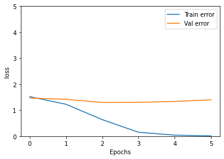

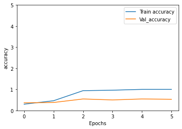

```python
plot_history(history_nn)
```

```python
#classification matrix

from sklearn.metrics import classification_report

# y_preds = np.argmax(tfidf_model.predict(X_test_tf.toarray()),axis=1)
# print(classification_report(np.argmax(y_test_new,axis=1),y_preds))

y_pred = tfidf_model.predict(X_test_tf.toarray(), verbose=0) # Multiclass
y_pred_index =  np.argmax(y_pred,axis=1)
y_original = np.argmax(y_test_new.to_numpy(), axis =1)
```

```python
print(classification_report(y_original, y_pred_index))
```

```
              precision    recall  f1-score   support

           0       0.67      0.50      0.57         4
           1       0.44      0.38      0.41        21
           2       0.50      0.50      0.50        22
           3       0.42      0.59      0.49        27
           4       0.00      0.00      0.00         9

    accuracy                           0.45        83
   macro avg       0.41      0.39      0.39        83
weighted avg       0.41      0.45      0.42        83
```

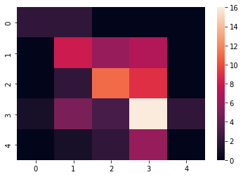

```python
sns.heatmap(confusion_matrix(y_original,y_pred_index))
```

```python
import pickle
pickle.dump(tfidf_model, open('/content/drive/MyDrive/Capstone/nn.pickle', 'wb'))
```

```
INFO:tensorflow:Assets written to: ram://f54475c5-ab98-4b80-8b06-7ac698b0b652/assets
```

```python
tfidf_model.save('/content/drive/MyDrive/Capstone/nn_base_model.h5')
# model.save('my_model.h5')
```

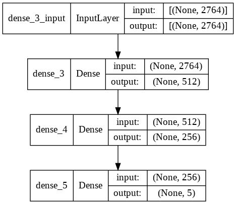

```python
# ann_viz(tfidf_model, view=True, filename="tfidf_model")
tf.keras.utils.plot_model(tfidf_model, to_file='tfidf_model.png', show_shapes=True, show_layer_names=True)
```

The accuracy using BOW is more or less similar to those we got using TF-IDF

### LSTM

```python
# Select input and output features

X_text = industry_df['Description_preprocessed']
y_text = industry_df['Potential_Accident_Level']
```

```python
# Encode labels in column 'Potential Accident Level'and Convert into one-hot encoded vectors:
y_text = LabelEncoder().fit_transform(y_text)
y_text = np_utils.to_categorical(y_text)
```

```python
# The first step in word embeddings is to convert the words into thier corresponding numeric indexes.
tokenizer = Tokenizer(num_words=5000)
tokenizer.fit_on_texts(X_text)
```

```python
# Divide our data into testing and training sets:
X_text_train, X_text_test, y_text_train, y_text_test = train_test_split(X_text, y_text, test_size = 0.30, random_state = 1)

print('X_text_train shape : ({0})'.format(X_text_train.shape))
print('y_text_train shape : ({0},)'.format(y_text_train.shape))
print('X_text_test shape : ({0})'.format(X_text_test.shape))
print('y_text_test shape : ({0},)'.format(y_text_test.shape))
```

```
X_text_train shape : ((287,))
y_text_train shape : ((287, 5),)
X_text_test shape : ((124,))
y_text_test shape : ((124, 5),)
```

```python
X_text_train = tokenizer.texts_to_sequences(X_text_train)
X_text_test = tokenizer.texts_to_sequences(X_text_test)
```

```python
industry_df['nb_words'] = industry_df['Description_preprocessed'].apply(lambda x: len(x.split(' ')))

print('Minimum number of words: {}'.format(industry_df['nb_words'].min()))
print('Maximum number of words: {}'.format(industry_df['nb_words'].max()))
```

```
Minimum number of words: 16
Maximum number of words: 183
```

```python
vocab_size = len(tokenizer.word_index) + 1
print("vocab_size:", vocab_size)

maxlen = 200

X_text_train = pad_sequences(X_text_train, padding='post', maxlen=maxlen)
X_text_test = pad_sequences(X_text_test, padding='post', maxlen=maxlen)
```

```
vocab_size: 3144
```

```python
!wget http://nlp.stanford.edu/data/glove.6B.zip
!unzip glove*.zip
```

[output not shown]

```python
!ls
!pwd
```

[output not shown]

```python
print('Indexing word vectors.')

embeddings_dictionary = {}
f = open('glove.6B.200d.txt', encoding='utf-8')
for line in f:
    values = line.split()
    word = values[0]
    coefs = np.asarray(values[1:], dtype='float32')
    embeddings_dictionary[word] = coefs
f.close()

print('Found %s word vectors.' % len(embeddings_dictionary))
```

```
Indexing word vectors.
Found 400000 word vectors.
```

```python
import pickle
pickle.dump({'embeddings_dictionary' : embeddings_dictionary } , open('/content/drive/MyDrive/AIML/Capstone/embeddings_dictionary.pickle', 'wb'))
```

```python
import pickle
infile = open('/content/drive/MyDrive/AIML/Capstone/embeddings_dictionary.pickle','rb')
embeddings_dictionary = pickle.load(infile)
```

```python
embedding_size = 200

embedding_matrix = np.zeros((vocab_size, embedding_size))

for word, index in tokenizer.word_index.items():
    embedding_vector = embeddings_dictionary.get(word)
    if embedding_vector is not None:
        embedding_matrix[index] = embedding_vector
embedding_matrix.shape
```

```
(3144, 200)
```

```python
base_model = Sequential()
base_model.add(Embedding(vocab_size, output_dim=embedding_size, weights=[embedding_matrix], input_length=200, trainable=True))
#LSTM
base_model.add(Bidirectional(LSTM(units=128 , recurrent_dropout = 0.5 , dropout = 0.5)))
base_model.add(Dense(5, activation='sigmoid'))
base_model.compile(optimizer=optimizers.Adam(lr = 0.001), loss='binary_crossentropy', metrics=['acc'])
```

```python
base_model.summary()
```

```
Model: "sequential_3"
_________________________________________________________________
 Layer (type)                Output Shape              Param #
=================================================================
 embedding_3 (Embedding)     (None, 200, 200)          628800

 bidirectional_3 (Bidirectio  (None, 256)              336896
 nal)

 dense_3 (Dense)             (None, 5)                 1285

=================================================================
Total params: 966,981
Trainable params: 966,981
Non-trainable params: 0
_________________________________________________________________
```

```python
X_text_train.shape,y_text_train.shape,X_text_test.shape, y_text_test.shape
```

```
((287, 200), (287, 5), (124, 200), (124, 5))
```

```python
callback = tf.keras.callbacks.EarlyStopping(monitor='loss', patience=3, min_delta=0.001)
rlrp = ReduceLROnPlateau(monitor='val_loss', factor=0.001, patience=3, min_delta=1E-4)

# fit the keras model on the dataset
base_model_history = base_model.fit(X_text_train, y_text_train, epochs=10, batch_size=8, verbose=1, validation_data=(X_text_test, y_text_test), callbacks=[rlrp])
```

```python
_, train_accuracy = base_model.evaluate(X_text_train, y_text_train, batch_size=8, verbose=0)
_, test_accuracy = base_model.evaluate(X_text_test, y_text_test, batch_size=8, verbose=0)

print('Train accuracy: %.2f' % (train_accuracy*100))
print('Test accuracy: %.2f' % (test_accuracy*100))
```

```
Train accuracy: 94.43
Test accuracy: 30.65
```

```python
# get the accuracy, precision, recall, f1 score from model
def get_classification_metrics(model, X_test, y_test, target_type):

  # predict probabilities for test set
  yhat_probs = model.predict(X_test, verbose=0) # Multiclass

  # predict crisp classes for test set
  if target_type == 'multi_class':
    yhat_classes = model.predict_classes(X_test, verbose=0) # Multiclass
  else:
    yhat_classes = (np.asarray(model.predict(X_test)).round()) # Multilabel

  # reduce to 1d array
  yhat_probs = yhat_probs[:, 0]

  # accuracy: (tp + tn) / (p + n)
  accuracy = accuracy_score(y_test, yhat_classes)

  # precision tp / (tp + fp)
  precision = precision_score(y_test, yhat_classes, average='micro')

  # recall: tp / (tp + fn)
  recall = recall_score(y_test, yhat_classes, average='micro')

  # f1: 2 tp / (2 tp + fp + fn)
  f1 = f1_score(y_test, yhat_classes, average='micro')

  return accuracy, precision, recall, f1
```

```python
class Metrics(tf.keras.callbacks.Callback):

    def __init__(self, validation_data=()):
        super().__init__()
        self.validation_data = validation_data

    def on_train_begin(self, logs={}):
        self.val_f1s = []
        self.val_recalls = []
        self.val_precisions = []

    def on_epoch_end(self, epoch, logs={}):
        xVal, yVal, target_type = self.validation_data
        if target_type == 'multi_class':
          val_predict_classes = model.predict_classes(xVal, verbose=0) # Multiclass
        else:
          val_predict_classes = (np.asarray(self.model.predict(xVal))).round() # Multilabel


        val_targ = yVal

        _val_f1 = f1_score(val_targ, val_predict_classes, average='micro')
        _val_recall = recall_score(val_targ, val_predict_classes, average='micro')
        _val_precision = precision_score(val_targ, val_predict_classes, average='micro')
        self.val_f1s.append(_val_f1)
        self.val_recalls.append(_val_recall)
        self.val_precisions.append(_val_precision)
        #print("— train_f1: %f — train_precision: %f — train_recall %f" % (_val_f1, _val_precision, _val_recall))
        return
```

```python
# Build a LSTM Neural Network
deep_inputs = Input(shape=(maxlen,))
embedding_layer = Embedding(vocab_size, embedding_size, weights=[embedding_matrix], trainable=True)(deep_inputs)

LSTM_Layer_1 = Bidirectional(LSTM(128, return_sequences = True))(embedding_layer)
max_pool_layer_1 = GlobalMaxPool1D()(LSTM_Layer_1)
drop_out_layer_1 = Dropout(0.5, input_shape = (256,))(max_pool_layer_1)
dense_layer_1 = Dense(128, activation = 'relu')(drop_out_layer_1)
drop_out_layer_2 = Dropout(0.5, input_shape = (128,))(dense_layer_1)
dense_layer_2 = Dense(64, activation = 'relu')(drop_out_layer_2)
drop_out_layer_3 = Dropout(0.5, input_shape = (64,))(dense_layer_2)

dense_layer_3 = Dense(32, activation = 'relu')(drop_out_layer_3)
drop_out_layer_4 = Dropout(0.5, input_shape = (32,))(dense_layer_3)

dense_layer_4 = Dense(10, activation = 'relu')(drop_out_layer_4)
drop_out_layer_5 = Dropout(0.5, input_shape = (10,))(dense_layer_4)

dense_layer_5 = Dense(5, activation='softmax')(drop_out_layer_5)

lstm_model = Model(inputs=deep_inputs, outputs=dense_layer_5)

opt = optimizers.Adam(lr=0.001)
lstm_model.compile(loss='categorical_crossentropy', optimizer=opt, metrics=['acc'])
```

```python
print(lstm_model.summary())
```

```
Model: "model"
_________________________________________________________________
 Layer (type)                Output Shape              Param #
=================================================================
 input_1 (InputLayer)        [(None, 200)]             0

 embedding_4 (Embedding)     (None, 200, 200)          628800

 bidirectional_4 (Bidirectio  (None, 200, 256)         336896
 nal)

 global_max_pooling1d (Globa  (None, 256)              0
 lMaxPooling1D)

 dropout (Dropout)           (None, 256)               0

 dense_4 (Dense)             (None, 128)               32896

 dropout_1 (Dropout)         (None, 128)               0

 dense_5 (Dense)             (None, 64)                8256

 dropout_2 (Dropout)         (None, 64)                0

 dense_6 (Dense)             (None, 32)                2080

 dropout_3 (Dropout)         (None, 32)                0

 dense_7 (Dense)             (None, 10)                330

 dropout_4 (Dropout)         (None, 10)                0

 dense_8 (Dense)             (None, 5)                 55

=================================================================
Total params: 1,009,313
Trainable params: 1,009,313
Non-trainable params: 0
_________________________________________________________________
None
```

```python
!pip install plot_model
```

[figure not shown]

```python
from keras.utils.vis_utils import plot_model
tf.keras.utils.plot_model(lstm_model, to_file='model.png', show_shapes=True, show_dtype=True,
show_layer_names=True, rankdir='TB', expand_nested=False, dpi=96)
```

```python
callback = tf.keras.callbacks.EarlyStopping(monitor='loss', patience=3, min_delta=1E-3)
rlrp = ReduceLROnPlateau(monitor='val_loss', factor=0.001, patience=3, min_delta=1E-4)

target_type = 'multi_label'
metrics = Metrics(validation_data=(X_text_train, y_text_train, target_type))

# fit the keras model on the dataset
training_history = lstm_model.fit(X_text_train, y_text_train, epochs=30, batch_size=32, verbose=1, validation_data=(X_text_test, y_text_test), callbacks=[rlrp])
```

```python
# evaluate the keras model
_, train_accuracy = lstm_model.evaluate(X_text_train, y_text_train, batch_size=8, verbose=0)
_, test_accuracy = lstm_model.evaluate(X_text_test, y_text_test, batch_size=8, verbose=0)

print('Train accuracy: %.2f' % (train_accuracy*100))
print('Test accuracy: %.2f' % (test_accuracy*100))
```

```
Train accuracy: 33.80
Test accuracy: 33.06
```

```python
accuracy, precision, recall, f1 = get_classification_metrics(lstm_model, X_text_test, y_text_test, "multi-class")
print('Accuracy: %f' % accuracy)
print('Precision: %f' % precision)
print('Recall: %f' % recall)
print('F1 score: %f' % f1)
```

```
Accuracy: 0.000000
Precision: 0.000000
Recall: 0.000000
F1 score: 0.000000
```

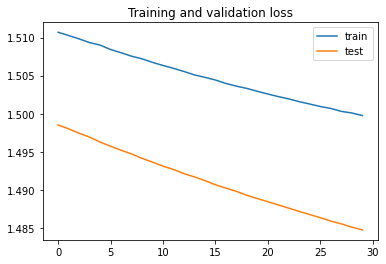

```python
epochs = range(len(training_history.history['loss'])) # Get number of epochs

# plot loss learning curves
plt.plot(epochs, training_history.history['loss'], label = 'train')
plt.plot(epochs, training_history.history['val_loss'], label = 'test')
plt.legend(loc = 'upper right')
plt.title ('Training and validation loss')
```

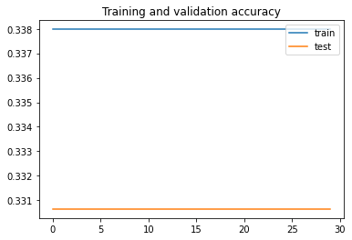

```python
# plot accuracy learning curves
plt.plot(epochs, training_history.history['acc'], label = 'train')
plt.plot(epochs, training_history.history['val_acc'], label = 'test')
plt.legend(loc = 'upper right')
plt.title ('Training and validation accuracy')
```